# LAB_5

Daniil Polishchuk

2024-05-06

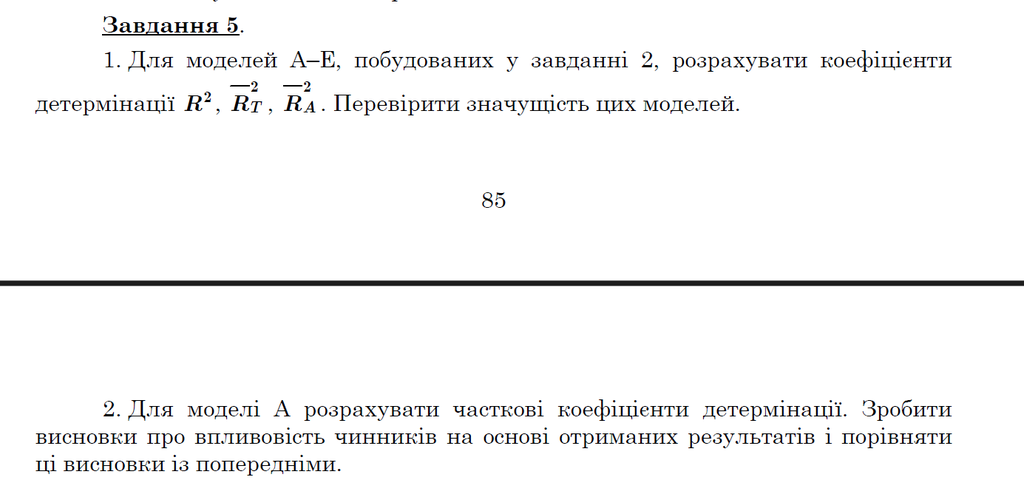

### Task 1

Для оцінки коефіцієнтів регресії використовується сума квадратів залишків. Її ми використовували для порівняння декількох моделей. Однак її не можна використовувати як показник адекватності однієї моделі, так як вона необмежена зверху. Відсутність верхньої межі у сумі квадратів залишків, як недолік, усувається за допомогою коефіцієнта детермінації.

Звичайний коефіцієнт детермінації $R^2$ як критерій вибору функції регресії має недолік, який може призвести до того, що буде віддаватися перевага варіанту рівняння з великою кількістю регресорів.

Цей недолік полягає в тому, що при включенні додаткового регресора до рівняння $R^2$ може тільки збільшитись.

На відміну від простого коефіцієнта детермінації $R^2$ , скоригований за Тейлом коефіцієнт детермінації коригується з урахуванням ступенів вільностей суми квадратів залишків та загальної суми квадратів.

Скоригований коефіцієнт детермінації R^A відображає втрату ступеня свободи при включенні додаткового регресора більш чітко, ніж R^T

```
               R^2       R^2_T       R^2_A   f.stat   f.test T/F
A       0.41788699 0.355960069  0.26926239 6.748067 2.412837   1
B - X2  0.08358994 0.065621115  0.01171464 4.651942 4.030393   1
c - X3  0.02579766 0.006695651 -0.05061037 1.350521 4.030393   0
D - X7  0.13342746 0.116435841  0.06546099 7.852546 4.030393   1
E - X12 0.04106195 0.022259245 -0.03414888 2.183832 4.030393   0
F - X13 0.02109097 0.001896680 -0.05568620 1.098815 4.030393   0
```

```
    X  pair.corr   part.corr sign.level T.F    t.test t.statistic T.F.1
1  X2  0.2891192  0.20687970 0.03575510   1 1.4496570    1.677927     0
2  X3 -0.1606165 -0.44772501 0.25059673   0 3.4327290    1.677927     1
3  X7  0.3652772  0.58094705 0.00715641   1 4.8931930    1.677927     1
4 X12 -0.2026375 -0.08014857 0.14561631   1 0.5512443    1.677927     0
5 X13 -0.1452273 -0.33415137 0.29946877   0 2.4305350    1.677927     1
```

# Task 2

Інтерпретація $ΔR_k^2$ : він показує, на яку величину зменшиться коефіцієнт детермінації, якщо k -й регресор виключити з моделі. Враховуючи суть коефіцієнта детермінації, можна зробити такий висновок: чим більший $ΔR_k^2$ , тим більш впливовим є у моделі k -й регресор.

```
            [,1]
data$X2  0.02603
data$X3  0.14594
data$X7  0.29655
data$X12 0.00376
data$X13 0.07317
```

Висновок: Ранжування зпівпало з частковим коєфікієнтом кореляції